# Projeto - Red Wine Quality

## Split dos dados

Crio os dados de treino e teste em cada escala para o treinamento dos algoritmos.

```r
# Min Max Scaler
splitMM = sample.split(best_df_trainMM$Densidade, SplitRatio = 0.80)
trainMM = subset(best_df_trainMM, splitMM == TRUE)
testMM = subset(best_df_trainMM, splitMM == FALSE)


# Scaler
splitS = sample.split(best_df_trainS$Densidade, SplitRatio = 0.80)
trainS = subset(best_df_trainS, splitS == TRUE)
testS = subset(best_df_trainS, splitS == FALSE)
```

## Balanceamento dos dados

Como já vimos temos que balancear a target em cada DF, pois está muito desbalanceada e pode tendenciar os modelos de aprendizagem. Passo duas vezes o smote, pois temos muitos poucos dados para treinar com ele eu aumento a quantidade dos dados e deixo balanceado.

```r
# Balanceando  a TrainMM
trainMM <- SMOTE(Qualidade ~ .,data =trainMM,perc.over = 10000, perc.under = 120)
trainMM <- SMOTE(Qualidade ~ .,data =trainMM,perc.over = 1000, perc.under = 210)
table(trainMM$Qualidade)
```

```
##
##    1    5   10
## 9178 9239 9647
```

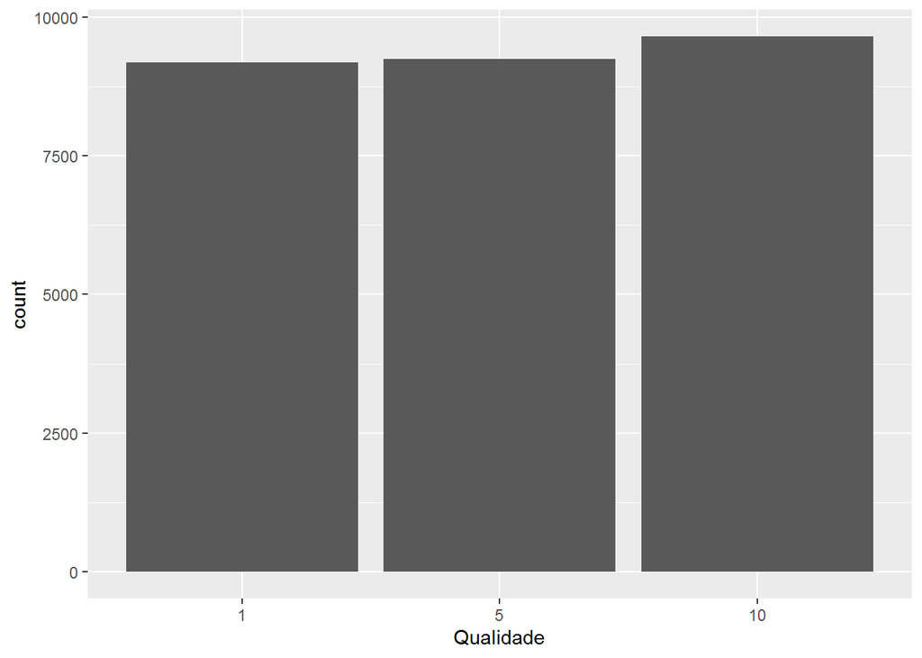

```r
ggplot(trainMM, aes(x = Qualidade)) + geom_bar()
```

```r
# Balanceando  a TrainS
trainS <- SMOTE(Qualidade ~ .,data =trainS,perc.over = 10000, perc.under = 120)
trainS <- SMOTE(Qualidade ~ .,data =trainS,perc.over = 1000, perc.under = 210)
table(trainS$Qualidade)
```

```
##
##    1    5   10
## 9310 9443 9823
```

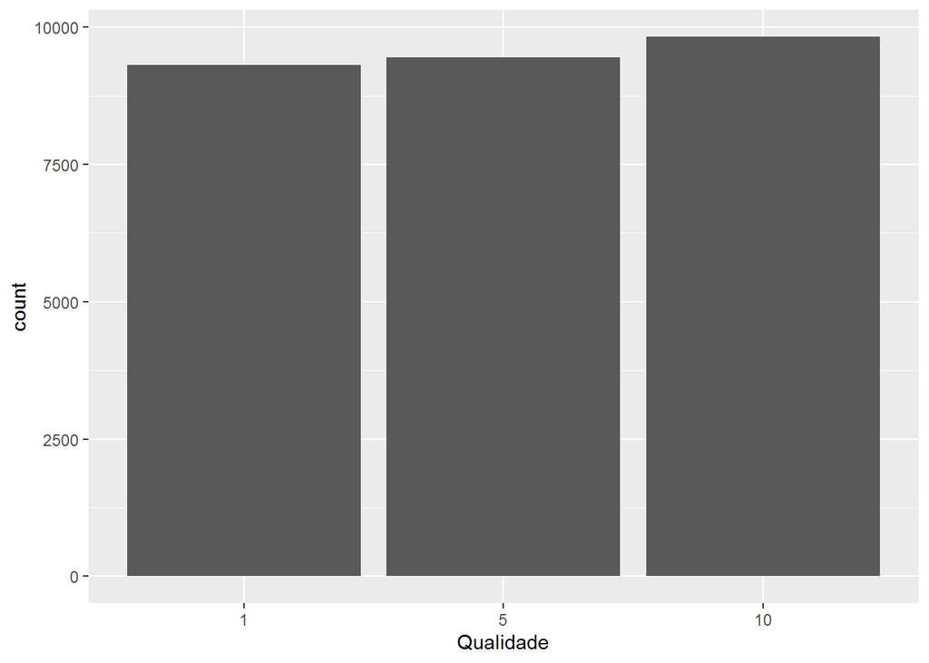

```r
ggplot(trainS, aes(x = Qualidade)) + geom_bar()
```

## Algoritmos de aprendizagem

### Dados com o Min Max Scaler

```r
# Modelo  com o KSVM  library(kernlab)

modelo_v1 <- ksvm(Qualidade ~ .
                  ,data= trainMM,type="C-bsvc", kernel = "rbfdot")
previsao_v1 <- predict(modelo_v1, testMM)
confusionMatrix(previsao_v1,testMM$Qualidade)
```

```
## Confusion Matrix and Statistics
##
##           Reference
## Prediction   1   5  10
##         1    7  32   2
##         5    3 173  14
##         10   1  21  24
##
## Overall Statistics
##
##                Accuracy : 0.7365
##                  95% CI : (0.6804, 0.7874)
##     No Information Rate : 0.8159
##     P-Value [Acc > NIR] : 0.9996
##
##                   Kappa : 0.358
##
##  Mcnemar's Test P-Value : 1.07e-05
##
## Statistics by Class:
##
##                      Class: 1 Class: 5 Class: 10
## Sensitivity           0.63636   0.7655   0.60000
## Specificity           0.87218   0.6667   0.90717
## Pos Pred Value        0.17073   0.9105   0.52174
## Neg Pred Value        0.98305   0.3908   0.93074
## Prevalence            0.03971   0.8159   0.14440
## Detection Rate        0.02527   0.6245   0.08664
## Detection Prevalence  0.14801   0.6859   0.16606
## Balanced Accuracy     0.75427   0.7161   0.75359
```

```r
# Modelo  com o RandomForest library('randomForest')
modelo_v2 <- randomForest(Qualidade ~ .
                  ,data= trainMM,ntree = 100,
                  nodesize = 10,method="repeatedcv",
                  number=15, repeats=10)
previsao_v2 <- predict(modelo_v2, testMM)
confusionMatrix(previsao_v2,testMM$Qualidade)
```

```
## Confusion Matrix and Statistics
##
##           Reference
## Prediction   1   5  10
##         1    6  16   0
##         5    5 201  18
##         10   0   9  22
##
## Overall Statistics
##
##                Accuracy : 0.8267
##                  95% CI : (0.7769, 0.8694)
##     No Information Rate : 0.8159
##     P-Value [Acc > NIR] : 0.3544
##
##                   Kappa : 0.46
##
##  Mcnemar's Test P-Value : NA
##
## Statistics by Class:
##
##                      Class: 1 Class: 5 Class: 10
## Sensitivity           0.54545   0.8894   0.55000
## Specificity           0.93985   0.5490   0.96203
## Pos Pred Value        0.27273   0.8973   0.70968
## Neg Pred Value        0.98039   0.5283   0.92683
## Prevalence            0.03971   0.8159   0.14440
## Detection Rate        0.02166   0.7256   0.07942
## Detection Prevalence  0.07942   0.8087   0.11191
## Balanced Accuracy     0.74265   0.7192   0.75601
```

```r
# Modelo svm do pacote library(e1071)
modelo_v3 <- svm(Qualidade ~ .
                          ,data= trainMM,type = 'C-classification',kernel = 'radial',
                          cost = 10, scale = FALSE,gamma = 0.1)
previsao_v3 <- predict(modelo_v3, testMM)
confusionMatrix(previsao_v3,testMM$Qualidade)
```

```
## Confusion Matrix and Statistics
##
##           Reference
## Prediction   1   5  10
##         1    9  56   2
##         5    2 129   9
##         10   0  41  29
##
## Overall Statistics
##
##                Accuracy : 0.6029
##                  95% CI : (0.5426, 0.6609)
##     No Information Rate : 0.8159
##     P-Value [Acc > NIR] : 1
##
##                   Kappa : 0.2667
##
##  Mcnemar's Test P-Value : 1.096e-15
##
## Statistics by Class:
##
##                      Class: 1 Class: 5 Class: 10
## Sensitivity           0.81818   0.5708    0.7250
## Specificity           0.78195   0.7843    0.8270
## Pos Pred Value        0.13433   0.9214    0.4143
## Neg Pred Value        0.99048   0.2920    0.9469
## Prevalence            0.03971   0.8159    0.1444
## Detection Rate        0.03249   0.4657    0.1047
## Detection Prevalence  0.24188   0.5054    0.2527
## Balanced Accuracy     0.80007   0.6776    0.7760
```

```r
# Modelo   naiveBayes do  pacote library(e1071)
modelo_v4 <- naiveBayes(Qualidade ~ .
                          ,data= trainMM, laplace=3)
previsao_v4 <- predict(modelo_v4, testMM, type="class")
confusionMatrix(previsao_v4,testMM$Qualidade)
```

```
## Confusion Matrix and Statistics
##
##           Reference
## Prediction   1   5  10
##         1    9  64   4
##         5    2 117   9
##         10   0  45  27
##
## Overall Statistics
##
##                Accuracy : 0.5523
##                  95% CI : (0.4917, 0.6119)
##     No Information Rate : 0.8159
##     P-Value [Acc > NIR] : 1
##
##                   Kappa : 0.2207
##
##  Mcnemar's Test P-Value : <2e-16
##
## Statistics by Class:
##
##                      Class: 1 Class: 5 Class: 10
## Sensitivity           0.81818   0.5177   0.67500
## Specificity           0.74436   0.7843   0.81013
## Pos Pred Value        0.11688   0.9141   0.37500
## Neg Pred Value        0.99000   0.2685   0.93659
## Prevalence            0.03971   0.8159   0.14440
## Detection Rate        0.03249   0.4224   0.09747
## Detection Prevalence  0.27798   0.4621   0.25993
## Balanced Accuracy     0.78127   0.6510   0.74256
```

```r
# Modelo com o C5.0 e library(C50)
modelo_v5 <- C5.0(Qualidade ~ .
                        ,data= trainMM,trials = 100)
previsao_v5 <- predict(modelo_v5, testMM)
confusionMatrix(previsao_v5,testMM$Qualidade)
```

```
## Confusion Matrix and Statistics
##
##           Reference
## Prediction   1   5  10
##         1    5  14   0
##         5    6 204  17
##         10   0   8  23
##
## Overall Statistics
##
##                Accuracy : 0.8375
##                  95% CI : (0.7887, 0.879)
##     No Information Rate : 0.8159
##     P-Value [Acc > NIR] : 0.1981
##
##                   Kappa : 0.4801
##
##  Mcnemar's Test P-Value : NA
##
## Statistics by Class:
##
##                      Class: 1 Class: 5 Class: 10
## Sensitivity           0.45455   0.9027   0.57500
## Specificity           0.94737   0.5490   0.96624
## Pos Pred Value        0.26316   0.8987   0.74194
## Neg Pred Value        0.97674   0.5600   0.93089
## Prevalence            0.03971   0.8159   0.14440
## Detection Rate        0.01805   0.7365   0.08303
## Detection Prevalence  0.06859   0.8195   0.11191
## Balanced Accuracy     0.70096   0.7258   0.77062
```

```r
# Modelo com o library(rpart)
modelo_v6 <- rpart(Qualidade ~ .
                        ,data= trainMM,control = rpart.control(cp = .0005), method = 'class')
previsao_v6 <- predict(modelo_v6, testMM, type = 'class')
confusionMatrix(previsao_v6,testMM$Qualidade)
```

```
## Confusion Matrix and Statistics
##
##           Reference
## Prediction   1   5  10
##         1    8  33   0
##         5    2 180  19
##         10   1  13  21
##
## Overall Statistics
##
##                Accuracy : 0.7545
##                  95% CI : (0.6995, 0.804)
##     No Information Rate : 0.8159
##     P-Value [Acc > NIR] : 0.9957
##
##                   Kappa : 0.3605
##
##  Mcnemar's Test P-Value : 1.69e-06
##
## Statistics by Class:
##
##                      Class: 1 Class: 5 Class: 10
## Sensitivity           0.72727   0.7965   0.52500
## Specificity           0.87594   0.5882   0.94093
## Pos Pred Value        0.19512   0.8955   0.60000
## Neg Pred Value        0.98729   0.3947   0.92149
## Prevalence            0.03971   0.8159   0.14440
## Detection Rate        0.02888   0.6498   0.07581
## Detection Prevalence  0.14801   0.7256   0.12635
## Balanced Accuracy     0.80161   0.6923   0.73296
```

### Dados com o Scaler

```r
# Modelo  com o KSVM  library(kernlab)

modelo_v7 <- ksvm(Qualidade ~ .
                  ,data= trainS,type="C-bsvc", kernel = "rbfdot")
previsao_v7 <- predict(modelo_v7, testS)
confusionMatrix(previsao_v7,testS$Qualidade)
```

```
## Confusion Matrix and Statistics
##
##           Reference
## Prediction   1   5  10
##         1    8  39   0
##         5    5 162   7
##         10   0  34  22
##
## Overall Statistics
##
##                Accuracy : 0.6931
##                  95% CI : (0.6352, 0.7469)
##     No Information Rate : 0.8484
##     P-Value [Acc > NIR] : 1
##
##                   Kappa : 0.2993
##
##  Mcnemar's Test P-Value : NA
##
## Statistics by Class:
##
##                      Class: 1 Class: 5 Class: 10
## Sensitivity           0.61538   0.6894   0.75862
## Specificity           0.85227   0.7143   0.86290
## Pos Pred Value        0.17021   0.9310   0.39286
## Neg Pred Value        0.97826   0.2913   0.96833
## Prevalence            0.04693   0.8484   0.10469
## Detection Rate        0.02888   0.5848   0.07942
## Detection Prevalence  0.16968   0.6282   0.20217
## Balanced Accuracy     0.73383   0.7018   0.81076
```

```r
# Modelo  com o RandomForest library('randomForest')
modelo_v8 <- randomForest(Qualidade ~ .
                          ,data= trainS,ntree = 100 ,
                          nodesize = 10,method="repeatedcv",
                          number=15, repeats=10)
previsao_v8 <- predict(modelo_v8, testS)
confusionMatrix(previsao_v8,testS$Qualidade)
```

```
## Confusion Matrix and Statistics
##
##           Reference
## Prediction   1   5  10
##         1    3  14   0
##         5   10 207   9
##         10   0  14  20
##
## Overall Statistics
##
##                Accuracy : 0.8303
##                  95% CI : (0.7808, 0.8726)
##     No Information Rate : 0.8484
##     P-Value [Acc > NIR] : 0.8224
##
##                   Kappa : 0.4191
##
##  Mcnemar's Test P-Value : NA
##
## Statistics by Class:
##
##                      Class: 1 Class: 5 Class: 10
## Sensitivity           0.23077   0.8809    0.6897
## Specificity           0.94697   0.5476    0.9435
## Pos Pred Value        0.17647   0.9159    0.5882
## Neg Pred Value        0.96154   0.4510    0.9630
## Prevalence            0.04693   0.8484    0.1047
## Detection Rate        0.01083   0.7473    0.0722
## Detection Prevalence  0.06137   0.8159    0.1227
## Balanced Accuracy     0.58887   0.7142    0.8166
```

```r
# Modelo svm do pacote library(e1071)
modelo_v9 <- svm(Qualidade ~ .
                 ,data= trainS,type = 'C-classification',
                 kernel = 'radial',cost = 10, scale = FALSE)
previsao_v9 <- predict(modelo_v9, testS)
confusionMatrix(previsao_v9,testS$Qualidade)
```

```
## Confusion Matrix and Statistics
##
##           Reference
## Prediction   1   5  10
##         1    5  34   0
##         5    8 172   8
##         10   0  29  21
##
## Overall Statistics
##
##                Accuracy : 0.7148
##                  95% CI : (0.6577, 0.7672)
##     No Information Rate : 0.8484
##     P-Value [Acc > NIR] : 1
##
##                   Kappa : 0.2847
##
##  Mcnemar's Test P-Value : NA
##
## Statistics by Class:
##
##                      Class: 1 Class: 5 Class: 10
## Sensitivity           0.38462   0.7319   0.72414
## Specificity           0.87121   0.6190   0.88306
## Pos Pred Value        0.12821   0.9149   0.42000
## Neg Pred Value        0.96639   0.2921   0.96476
## Prevalence            0.04693   0.8484   0.10469
## Detection Rate        0.01805   0.6209   0.07581
## Detection Prevalence  0.14079   0.6787   0.18051
## Balanced Accuracy     0.62791   0.6755   0.80360
```

```r
# Modelo   naiveBayes do  pacote library(e1071)
modelo_v10 <- naiveBayes(Qualidade ~ .
                        ,data= trainS, laplace=1)
previsao_v10 <- predict(modelo_v10, testS, type="class")
confusionMatrix(previsao_v10,testS$Qualidade)
```

```
## Confusion Matrix and Statistics
##
##           Reference
## Prediction   1   5  10
##         1    9  74   1
##         5    3 101   1
##         10   1  60  27
##
## Overall Statistics
##
##                Accuracy : 0.4946
##                  95% CI : (0.4342, 0.5551)
##     No Information Rate : 0.8484
##     P-Value [Acc > NIR] : 1
##
##                   Kappa : 0.1989
##
##  Mcnemar's Test P-Value : <2e-16
##
## Statistics by Class:
##
##                      Class: 1 Class: 5 Class: 10
## Sensitivity           0.69231   0.4298   0.93103
## Specificity           0.71591   0.9048   0.75403
## Pos Pred Value        0.10714   0.9619   0.30682
## Neg Pred Value        0.97927   0.2209   0.98942
## Prevalence            0.04693   0.8484   0.10469
## Detection Rate        0.03249   0.3646   0.09747
## Detection Prevalence  0.30325   0.3791   0.31769
## Balanced Accuracy     0.70411   0.6673   0.84253
```

```r
# Modelo com o C5.0 e library(C50)
modelo_v11 <- C5.0(Qualidade ~ .
                        ,data= trainS,trials = 100)
previsao_v11 <- predict(modelo_v11, testS)
confusionMatrix(previsao_v11,testS$Qualidade)
```

```
## Confusion Matrix and Statistics
##
##           Reference
## Prediction   1   5  10
##         1    3  10   0
##         5   10 211  10
##         10   0  14  19
##
## Overall Statistics
##
##                Accuracy : 0.8412
##                  95% CI : (0.7927, 0.8821)
##     No Information Rate : 0.8484
##     P-Value [Acc > NIR] : 0.6681
##
##                   Kappa : 0.4283
##
##  Mcnemar's Test P-Value : NA
##
## Statistics by Class:
##
##                      Class: 1 Class: 5 Class: 10
## Sensitivity           0.23077   0.8979   0.65517
## Specificity           0.96212   0.5238   0.94355
## Pos Pred Value        0.23077   0.9134   0.57576
## Neg Pred Value        0.96212   0.4783   0.95902
## Prevalence            0.04693   0.8484   0.10469
## Detection Rate        0.01083   0.7617   0.06859
## Detection Prevalence  0.04693   0.8339   0.11913
## Balanced Accuracy     0.59645   0.7108   0.79936
```

```r
# Modelo com o library(rpart)
modelo_v12 <- rpart(Qualidade ~ .
                   ,data= trainS,control = rpart.control(cp = .0005), method = 'class')
previsao_v12 <- predict(modelo_v12, testS, type = 'class')
confusionMatrix(previsao_v12,testS$Qualidade)
```

```
## Confusion Matrix and Statistics
##
##           Reference
## Prediction   1   5  10
##         1    4  40   1
##         5    9 173   8
##         10   0  22  20
##
## Overall Statistics
##
##                Accuracy : 0.7112
##                  95% CI : (0.6539, 0.7639)
##     No Information Rate : 0.8484
##     P-Value [Acc > NIR] : 1
##
##                   Kappa : 0.2681
##
##  Mcnemar's Test P-Value : 5.488e-06
##
## Statistics by Class:
##
##                      Class: 1 Class: 5 Class: 10
## Sensitivity           0.30769   0.7362    0.6897
## Specificity           0.84470   0.5952    0.9113
## Pos Pred Value        0.08889   0.9105    0.4762
## Neg Pred Value        0.96121   0.2874    0.9617
## Prevalence            0.04693   0.8484    0.1047
## Detection Rate        0.01444   0.6245    0.0722
## Detection Prevalence  0.16245   0.6859    0.1516
## Balanced Accuracy     0.57619   0.6657    0.8005
```

## Considerações Finais

Com a pouca quantidade de dados, a acurácia fica um pouco comprometida pois, o modelo não tem tantos dados para aprender, mesmo assim tivemos um bom aproveitamento com os modelos randomForest e o C5.0, tanto nos dados Min Max Scaler quanto no Scaler, escolheria algum desse modelos para os novos dados.

### Obrigado! Entre em contato comigo acessando meu portifolio (https://campos1989.github.io/) no menu contato!